# **Case Study: CAPM as a Regression Model**

### Dr. Andrés García Medina

### Email: andgarm.n@gmaiñ.com

### Site: https://sites.google.com/view/andresgm/home

**Model Definition**

In multiple linear regression, the general model is:

$ y = \beta_0 + \beta_1 x_1 + \cdots + \beta_p x_p + \varepsilon $

where:

- $y$: dependent variable
- $x_i$: independent variables
- $\beta_i$: parameters to estimate
- $\varepsilon$: error term

The CAPM (Capital Asset Pricing Model) can be written as a linear regression model:

$ R_i - R_f = \alpha + \beta (R_m - R_f) + \varepsilon $

where:

- $R_i$: return of the asset (GameStop)
- $R_m$: return of the market (S&P 500)
- $R_f$: risk-free rate
- $\beta$: systematic risk (sensitivity to the market)
- $\alpha$: abnormal return

Note: Sharpe, Markowitz and Merton Miller jointly received the 1990 Nobel Memorial Prize in Economic Sciences for this contribution to the field of financial economics.

### Beta (β)

- Measures how sensitive the asset is to market movements:
  - $ \beta = 1 $: asset moves with the market
  - $ \beta > 1 $: more volatile than the market (higher risk)
  - $ 0 < \beta < 1 $: less volatile than the market
  - $ \beta < 0 $: moves opposite to the market

### Alpha (α)

- Represents abnormal returns not explained by the market:
  - $ \alpha = 0 $: asset is correctly priced according to CAPM
  - $ \alpha > 0 $: asset outperforms CAPM prediction (positive abnormal return)
  - $ \alpha < 0 $: asset underperforms

#### Libraries

```python
import numpy as np
import pandas as pd
import yfinance as yf
import statsmodels.api as sm
import matplotlib.pyplot as plt
```

Data

```python
tickers = ["GME", "^GSPC"]
data = yf.download(tickers, start="2023-01-01", end="2026-03-17")
data.head()
```

| Price Ticker Date | Close GME | Close ^GSPC | High GME | High ^GSPC | Low GME | Low ^GSPC | Open GME | Open ^GSPC | Volume GME | Volume ^GSPC |
| --- | --- | --- | --- | --- | --- | --- | --- | --- | --- | --- |
| 2023-01-03 | 17.200001 | 3824.139893 | 19.260000 | 3878.459961 | 17.090000 | 3794.330078 | 18.639999 | 3853.290039 | 5135200 | 3959140000 |
| 2023-01-04 | 17.320000 | 3852.969971 | 17.930000 | 3873.159912 | 16.900000 | 3815.770020 | 17.250000 | 3840.360107 | 3939300 | 4414080000 |
| 2023-01-05 | 16.219999 | 3808.100098 | 17.260000 | 3839.739990 | 15.890000 | 3802.419922 | 17.059999 | 3839.739990 | 6066200 | 3893450000 |
| 2023-01-06 | 16.459999 | 3895.080078 | 16.570000 | 3906.189941 | 15.410000 | 3809.560059 | 16.000000 | 3823.370117 | 4823400 | 3923560000 |
| 2023-01-09 | 16.379999 | 3892.090088 | 17.129999 | 3950.570068 | 16.360001 | 3890.419922 | 16.650000 | 3910.820068 | 3522600 | 4311770000 |

```python
data.to_excel("stock_data.xlsx")
print("Data saved to stock_data.xlsx")
```

```
Data saved to stock_data.xlsx
```

### Compute log returns

```python
returns = np.log(data / data.shift(1)).dropna()
returns.head()
```

| Price Ticker Date | Close GME | Close ^GSPC | High GME | High ^GSPC | Low GME | Low ^GSPC | Open GME | Open ^GSPC | Volume GME | Volume ^GSPC |
| --- | --- | --- | --- | --- | --- | --- | --- | --- | --- | --- |
| 2023-01-04 | 0.006952 | 0.007511 | -0.071555 | -0.001367 | -0.011180 | 0.005635 | -0.077498 | -0.003361 | -0.265116 | 0.108773 |
| 2023-01-05 | -0.065617 | -0.011714 | -0.038084 | -0.008666 | -0.061624 | -0.003505 | -0.011076 | -0.000161 | 0.431729 | -0.125504 |
| 2023-01-06 | 0.014688 | 0.022584 | -0.040798 | 0.017158 | -0.030673 | 0.001876 | -0.064148 | -0.004272 | -0.229253 | 0.007704 |
| 2023-01-09 | -0.004872 | -0.000768 | 0.033237 | 0.011297 | 0.059823 | 0.021003 | 0.039821 | 0.022615 | -0.314280 | 0.094349 |
| 2023-01-10 | 0.081451 | 0.006954 | 0.054528 | -0.007812 | -0.006746 | -0.003381 | -0.021245 | -0.005706 | 0.223041 | -0.113008 |

### Define CAPM variables

```python
R_i = returns['Close']['GME']
R_m = returns['Close']['^GSPC']

# Risk-free rate (approx. constant daily)
Rf = 0.02 / 252  # 2% annually

# Excess returns
Y = R_i - Rf
X = R_m - Rf
```

### Estimate regression (OLS)

```python
# Add constant (intercept)
X = sm.add_constant(X)

model = sm.OLS(Y, X).fit()

# Results
print(model.summary())
```

```
                            OLS Regression Results
==============================================================================
Dep. Variable:                    GME   R-squared:                       0.033
Model:                            OLS   Adj. R-squared:                  0.031
Method:                 Least Squares   F-statistic:                     26.84
Date:                Thu, 17 Sep 2026   Prob (F-statistic):           2.80e-07
Time:                        08:31:53   Log-Likelihood:                 1143.8
No. Observations:                 801   AIC:                            -2284.
Df Residuals:                     799   BIC:                            -2274.
Df Model:                           1
Covariance Type:            nonrobust
==============================================================================
                 coef    std err          t      P>|t|      [0.025      0.975]
------------------------------------------------------------------------------
const         -0.0004      0.002     -0.197      0.843      -0.004       0.004
^GSPC          1.1356      0.219      5.181      0.000       0.705       1.566
==============================================================================
Omnibus:                      370.290   Durbin-Watson:                   1.943
Prob(Omnibus):                  0.000   Jarque-Bera (JB):            28150.260
Skew:                           1.192   Prob(JB):                         0.00
Kurtosis:                      31.944   Cond. No.                         107.
==============================================================================

Notes:
[1] Standard Errors assume that the covariance matrix of the errors is correctly specified.
```

### Visualization

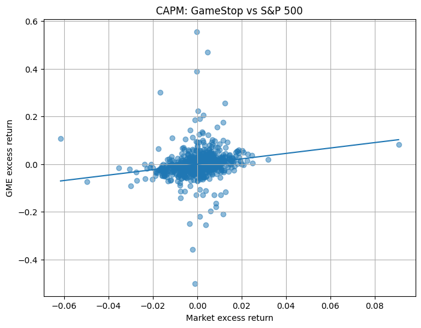

```python
plt.figure(figsize=(8,6))
plt.scatter(X.iloc[:,1], Y, alpha=0.5)

# Regression line
beta = model.params[1]
alpha = model.params[0]

x_vals = np.linspace(X.iloc[:,1].min(), X.iloc[:,1].max(), 100)
y_vals = alpha + beta * x_vals

plt.plot(x_vals, y_vals)

plt.xlabel("Market excess return")
plt.ylabel("GME excess return")
plt.title("CAPM: GameStop vs S&P 500")
plt.grid()
plt.show()
```